# Task 8

### Packages required: **Terra** & **leaflet**

```r
library(terra)
library(leaflet)
```

Read this article, it gives a good overview of remote sensing and why band calculations work. [NDVI, NDBI, NDWI Calculation Using Landsat 7/8](https://www.linkedin.com/pulse/ndvi-ndbi-ndwi-calculation-using-landsat-7-8-tek-bahadur-kshetri)

### Part 1 final product: **Create these two plots**

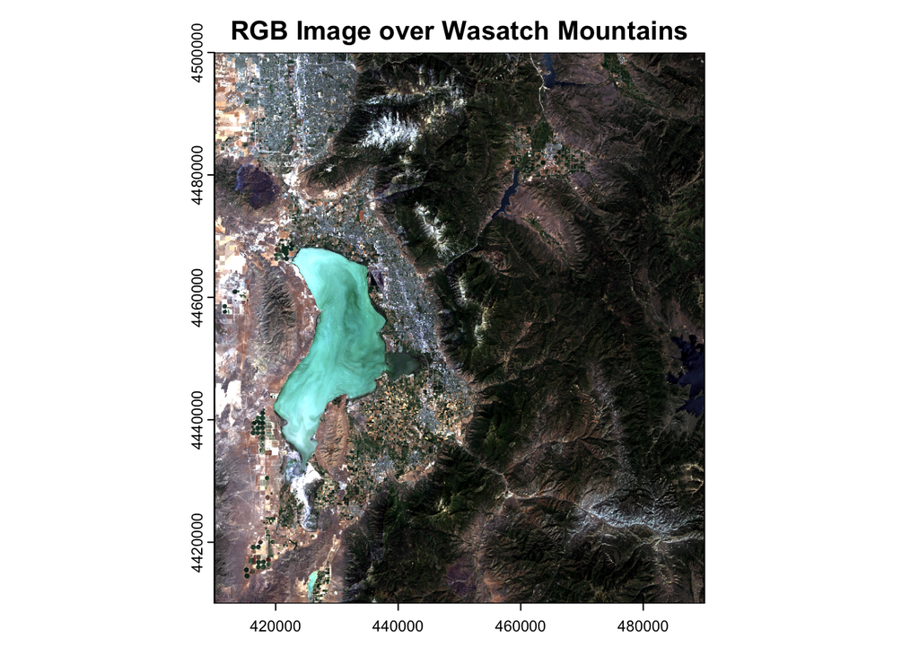

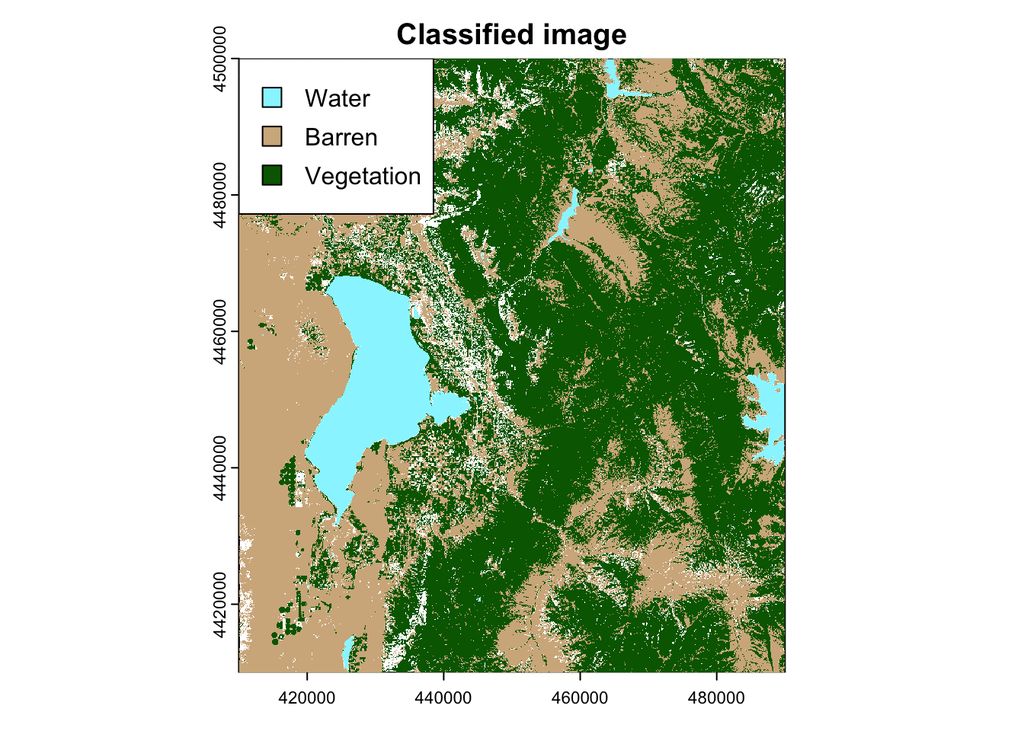

The Normalized Difference Vegetation Index (NDVI) is calculated as:

$$NDVI = \frac{(NIR - Red)}{(NIR + Red)}$$

where NIR represents the Near Infrared band **(Band 4)** and the Red band **(Band 3)** for Landsat 7.

The Modified Normalized Difference Water Index (MNDWI) is calculated as:

$$MNDWI = \frac{(Green - SWIR)}{(Green + SWIR)}$$

where Green represents the Green band **(Band 2)** and SWIR represents the Shortwave Infrared band **(Band 5)** of Landsat 7.

The Normalized Difference Built-Up Index (NDBI) is typically used to see areas of urban development, but it works well with this image to calculate barren land, it is calculated as:

$$NDBI = \frac{(SWIR - NIR)}{(SWIR + NIR)}$$

where SWIR represents the Shortwave Infrared band **(Band 5)** and NIR represents the Near Infrared band **(Band 4)** of Landsat 7.

### Steps:

-Download the landsat 7 image.

-Read in the image.

-Do band caluclations for MNDWI, NDBI, and NDVI

-Create threshold for those band calculations so they are true/false values

-Plot all three band calculation thresholds on the same image

-Add Legend with corresponding colors

*Hints:*

What if my RGB plot is really dark?

```r
# If your plotRGB plot is really dark this is because the image needs to be stretch. There are a few different stretch methods:

# stretch = "lin"
# This stretch method applies a linear stretch of values across the image

# stretch = "hist"
# This stretch method applies a histogram stretch of values across the image
```

What if my classification map does not look like the expected product?

```r
# This may not be an issue and is just due to your threshold being different than mine for each index.
# These are the values I used
# MNDWI > 0
# NDBI > 0
# NDVI > 0.2
```

What if I can’t get the false values to be transparent?

```r
# After creating a threshold for the indexes you can plot them with transparent false values like so in the plot function: col = c("transparent","cadetblue1") This sets the false value color first and then the true value color.
```

How do I access specific layers in a raster with multiple layers?

```r
# You can access a specific layer through indexing, it's a little different for raster you use double brackets. EX:  image[[x]] with x being the layer number you want to grab. Be careful assuming that each index number directly correlated to the band number, they may be out of order!
```

### Part 2 final product:

```r
dem <- rast("../../DEMs/timp/output_USGS1m.tif")

c1 <- crop(dem,c(442000,448000,4470000,4474000))
c2 <- crop(dem,c(443000,449000,4467000,4471000))

c1 <- aggregate(c1,10)
c2 <- aggregate(c2,10)

aspect <- terrain(mosaic(c1,c2),"aspect")
slope <- terrain(mosaic(c1,c2),"slope")

mos <- mosaic(c1,c2)

leaflet()%>%
  addProviderTiles("OpenStreetMap.HOT") %>%
  addRasterImage(shade(slope*pi/180, aspect*pi/180, angle = 40, direction = 270), col = grey(0:100/100)) %>%
  addMiniMap()
```

[interactive chart not shown]

### Steps:

-Download the DEMs

-Mosaic the DEMs together

-Create an aspect and slope map

-Create a hillshade map with the aspect and slope map

-Plot a leaflet map with a few different options (minimap, bounding box, etc…)

Copy this and figure out how to add the mosaic of the DEM. Add a few different elements like a minimap and try to add some fun stuff!

The way that I’ve gone about discovering the possibilities of the leaflet package is by typing **leaflet::** and seeing all of the functions that it has!

```r
leaflet()%>%
  addProviderTiles("OpenStreetMap.HOT")
```

*Hints:*

How do I make a hillshade from a slope and aspect map?

```r
# shade(slope*pi/180, aspect*pi/180, angle = 40, direction = 270)

# col = grey(0:100/100)
```